# Capítulo20

Ramón Álvarez-Vaz

2023-11-19

# 1 Transformaciones

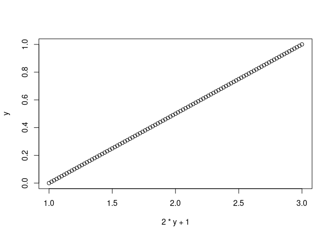

```r
y<-seq(0,1,0.01)
plot(2*y+1,y)
```

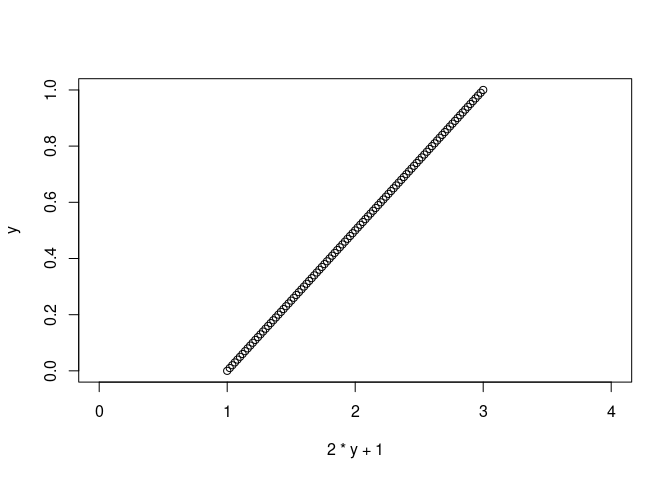

```r
plot(2*y+1,y,xlim=c(0,4))
```

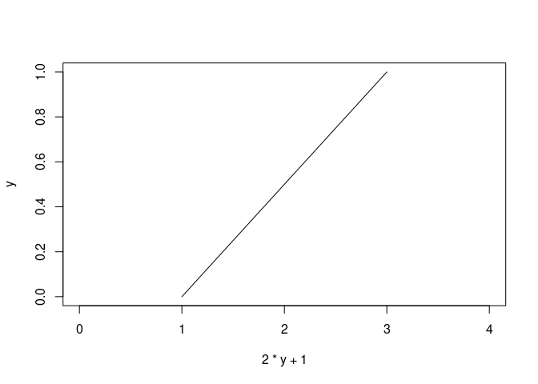

```r
plot(2*y+1,y,xlim=c(0,4),type="l")
```

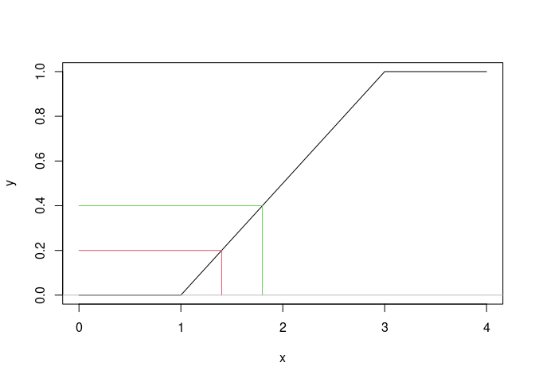

```r
x<-c(seq(0,1,0.01),2*y+1,seq(3,4,0.01))
y<-c(rep(0,101),y,rep(1,101))

f<-function(x)return(2*x+1)

plot(x,y,type="l")
segments(0,0.2,f(0.2),0.2,col=2)
segments(0,0.4,f(0.4),0.4,col=3)
segments(f(0.2),0,f(0.2),0.2,col=2)
segments(f(0.4),0,f(0.4),0.4,col=3)
abline(h=0,col="grey")
```

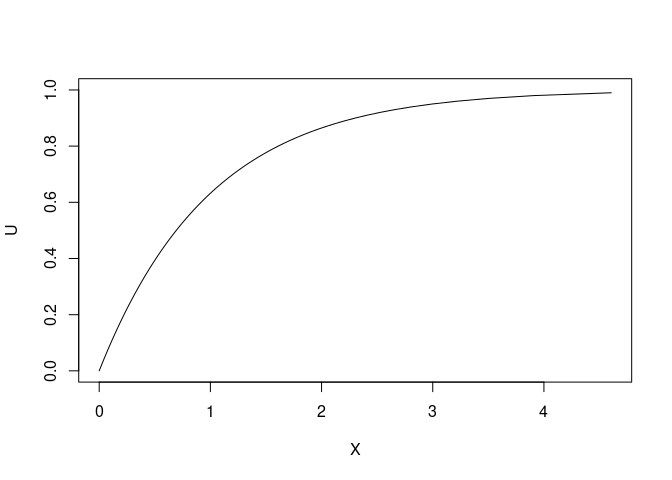

```r
g<-function(x)return(-log(1-x))
z<-seq(0,1,0.01)
plot(g(z),z,type="l",ylab="U",xlab="X")
```

# 2 Con curve

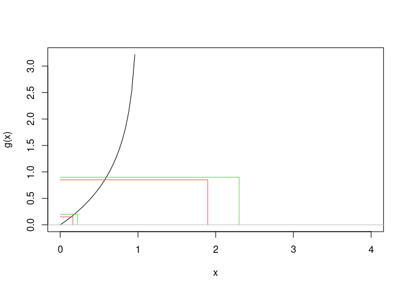

```r
curve(g,0,4)
segments(0,0.15,g(0.15),0.15,col=2)
segments(0,0.2,g(0.2),0.2,col=3)
segments(g(0.15),0,g(0.15),0.15,col=2)
segments(g(0.2),0,g(0.2),0.2,col=3)
segments(0,0.85,g(0.85),0.85,col=2)
segments(0,0.9,g(0.9),0.9,col=3)
segments(g(0.85),0,g(0.85),0.85,col=2)
segments(g(0.9),0,g(0.9),0.9,col=3)

abline(h=0,col="grey")
```

# 3 Como son las funciones que simulan distribuciones en R?

## 3.1 Random.seed

Es un vector de enteros, que contiene el estado del generador de números aleatorios (RNG) con el que va generar de números aleatorios en R. Se puede guardar y restaurar, pero no debe ser alterada por el usuario.

## 3.2 Wichmann-Hill

The seed, .Random.seed[-1] == r[1:3] is an integer vector of length 3, where each r[i] is in 1:(p[i] - 1), where p is the length 3 vector of primes, p = (30269, 30307, 30323). The Wichmann–Hill generator has a cycle length of 6.9536e12 (= prod(p-1)/4, see Applied Statistics (1984) 33, 123 which corrects the original article).

## 3.3 Marsaglia-Multicarry”:

A multiply-with-carry RNG is used, as recommended by George Marsaglia in his post to the mailing list ‘sci.stat.math’. It has a period of more than 2^60 and has passed all tests (according to Marsaglia). The seed is two integers (all values allowed).

## 3.4 Super-Duper

Marsaglia’s famous Super-Duper from the 70’s. This is the original version which does not pass the MTUPLE test of the Diehard battery. It has a period of about 4.6*10^18 for most initial seeds. The seed is two integers (all values allowed for the first seed: the second must be odd).

```r
 set.seed(42)
runif(2)
```

```
## [1] 0.9148060 0.9370754
```

```r
#[1] 0.9148060 0.9370754
 RNG.state <- .Random.seed
 runif(2)
```

```
## [1] 0.2861395 0.8304476
```

```r
#[1] 0.2861395 0.8304476
 set.seed(42)
 runif(4)
```

```
## [1] 0.9148060 0.9370754 0.2861395 0.8304476
```

```r
#[1] 0.9148060 0.9370754 0.2861395 0.8304476
 .Random.seed <- RNG.state
 runif(2)
```

```
## [1] 0.2861395 0.8304476
```

```r
#[1] 0.2861395 0.8304476
```

# 4 Ejemplo extraido de Robert and Casella

```r
Nsim=10^2
y=runif(Nsim)
y1=y[-Nsim]
y2=y[-1]
head(data.frame(y1,y2))
```

```
##          y1        y2
## 1 0.6417455 0.5190959
## 2 0.5190959 0.7365883
## 3 0.7365883 0.1346666
## 4 0.1346666 0.6569923
## 5 0.6569923 0.7050648
## 6 0.7050648 0.4577418
```

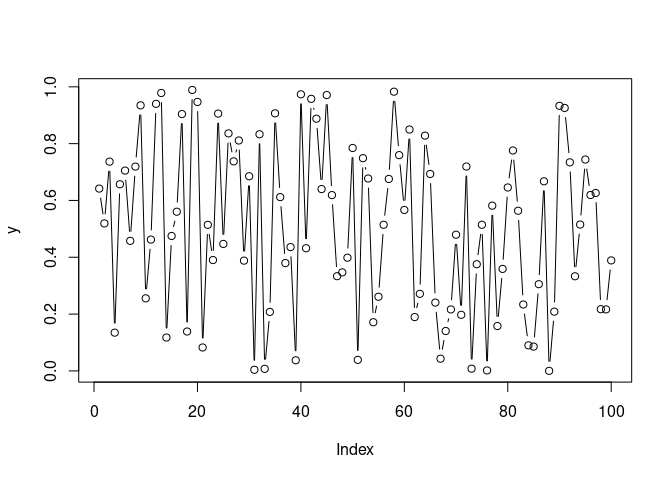

```r
plot(y,type="b")
```

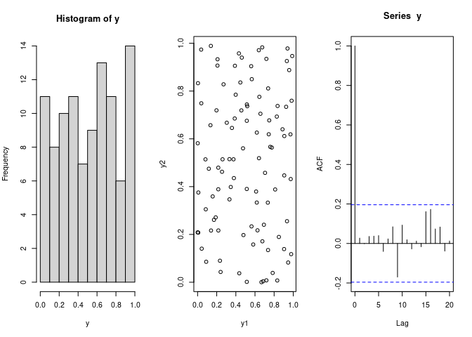

```r
par(mfrow=c(1,3))
hist(y)
plot(y1,y2)
acf(y)
```

```r
Nsim=10^4
```

# 5 Number of random variables

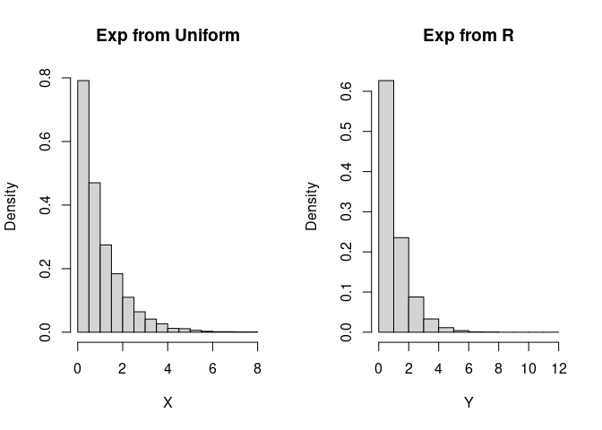

```r
U=runif(Nsim)
X=-log(U)
#transforms of uniforms
Y=rexp(Nsim)
#exponentials from R
par(mfrow=c(1,2))
#plots
hist(X,freq=F,main="Exp from Uniform")
hist(Y,freq=F,main="Exp from R")
```

# 6 Funciones para simular distribuciones

```r
binom.cdf <- function(x, n, p) {
    Fx <- 0
  for (i in 0:x) {
    Fx <- Fx + choose(n, i)*p^i*(1-p)^(n-i)
     }
  return(Fx)
}

n<-10
p<-0.2
y<-matrix(0,n+1,2)
for (i in 1:n+1)
{y[i,1]<-i-1
y[i,2]<-binom.cdf(i-1,n,p)}

cdf.sim <- function(F, ...) {
  X <- 0
  cont<-1
  U <- runif(1)
  while (F(X, ...) < U) {
    X <- X + 1
    cont<-cont+1
    print(cont)
  }
  return(list(X,cont))
}

binom.sim <- function(n, p) {
  X <- 0
  px <- (1-p)^n
  Fx <- px
  U <- runif(1)
  while (Fx < U) {
    X <- X + 1
    px <- ((n-X+1)*p*px)/((1-p)*X)
    Fx <- Fx + px
  }
  return(X)
}

cdf.sim(binom.cdf, 100, 0.2)
```

```
## [1] 2
## [1] 3
## [1] 4
## [1] 5
## [1] 6
## [1] 7
## [1] 8
## [1] 9
## [1] 10
## [1] 11
## [1] 12
## [1] 13
## [1] 14
## [1] 15
## [1] 16
## [1] 17
## [1] 18
## [1] 19
## [1] 20
```

```
## [[1]]
## [1] 19
##
## [[2]]
## [1] 20
```

# 7 inputs

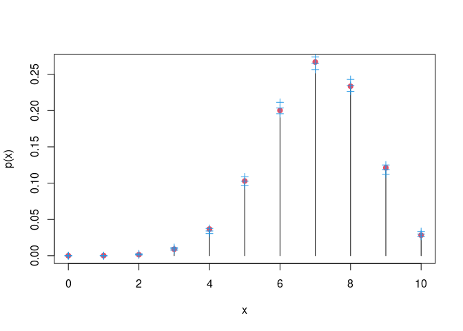

```r
par(mfrow=c(1,1))
N <- 10000
n <- 10
p <- 0.7
set.seed(100)
# sample size
# rv parameters
# seed for RNG
# generate sample and estimate p
X <- rep(0, N)
for (i in 1:N) X[i] <- binom.sim(n, p)
phat <- rep(0, n+1)
for (i in 0:n) phat[i+1] <- sum(X == i)/N
phat.CI <- 1.96*sqrt(phat*(1-phat)/N)
# plot output
plot(0:n, dbinom(0:n, n, p), type="h", xlab="x", ylab="p(x)")
points(0:n, dbinom(0:n, n, p), pch=19,col=2)
points(0:n, phat, pch=3,col=4)
points(0:n, phat+phat.CI, pch=3,col=4)
points(0:n, phat-phat.CI, pch=3,col=4)
```

```r
# t<-10000
# x<-matrix(0,t,3)
# x[1,1]<-X_0



X <- 0
for (i in 1:n) {
  U <- runif(1)
  if (U < p) X <- X + 1
}

(X <- sum(runif(n) < p))
```

```
## [1] 9
```

```r
test1<-function(){U=runif(3*10^4)
U=matrix(data=U,nrow=3)
X=-log(U)
X=2* apply(X,2,sum)}

system.time(test1())
```

```
##    user  system elapsed
##   0.016   0.000   0.016
```

```r
test2<-function(){X=rchisq(10^4,df=6)}
#sumamos las chicuadrados
system.time(test2())
```

```
##    user  system elapsed
##   0.001   0.000   0.002
```

# 8 Descomposición de Cholesky

En álgebra, la factorización o *descomposición de Cholesky* [https://es.wikipedia.org/wiki/Factorizaci%C3%B3n_de_Cholesky] toma su nombre del matemático André-Louis Cholesky, quien encontró que una matriz simétrica definida positiva puede ser descompuesta como el producto de una matriz triangular inferior y la traspuesta de la matriz triangular inferior. La matriz *triangular inferior* es el triángulo de Cholesky de la matriz original positiva definida. El resultado de Cholesky ha sido extendido a matrices con entradas complejas. Es una manera de resolver sistemas de ecuaciones matriciales y se deriva de la factorización $LU$ con una pequeña variación.

Cualquier matriz cuadrada $A$ con pivotes no nulos puede ser escrita como el producto de una matriz triangular inferior $L$ y una matriz triangular superior $U$; esto recibe el nombre de factorización $LU$. Sin embargo, si $A$ es simétrica y definida positiva, se pueden escoger los factores tales que $U$ es la transpuesta de $L$, y esto se llama la descomposición o factorización de Cholesky. Tanto la descomposición $LU$ como la descomposición de Cholesky son usadas para resolver sistemas de ecuaciones lineales. Cuando es aplicable, la descomposición de Cholesky es dos veces más eficiente que la descomposición $LU$.

El Algoritmo $QR$ es un algoritmo usado en álgebra lineal para el cálculo de valores y vectores propios de una matriz. Se basa en la descomposición $QR$

```r
( m <- matrix(c(5,1,1,3),2,2) )
```

```
##      [,1] [,2]
## [1,]    5    1
## [2,]    1    3
```

```r
( cm <- chol(m) )
```

```
##          [,1]      [,2]
## [1,] 2.236068 0.4472136
## [2,] 0.000000 1.6733201
```

```r
t(cm) %*% cm  #-- = 'm'
```

```
##      [,1] [,2]
## [1,]    5    1
## [2,]    1    3
```

```r
crossprod(cm)  #-- = 'm'
```

```
##      [,1] [,2]
## [1,]    5    1
## [2,]    1    3
```

```r
x <- matrix(c(1:5, (1:5)^2), 5, 2)
x <- cbind(x, x[, 1] + 3*x[, 2])
colnames(x) <- letters[20:22]
m <- crossprod(x)
qr(m)$rank # is 2, as it should be
```

```
## [1] 2
```

*chol()* puede fallar, dependiendo del redondeo numérico: *chol()* a diferencia de qr() no utiliza una tolerancia.

```r
try(chol(m))
```

```
## Error in chol.default(m) : the leading minor of order 3 is not positive
```

```r
(Q <- chol(m, pivot = TRUE))
```

```
##          v        t          u
## t 101.0742 7.222415 31.2839385
## u   0.0000 1.684259 -0.5614195
## attr(,"pivot")
## [1] 3 1 2
## attr(,"rank")
## [1] 2
```

```r
## we can use this by
pivot <- attr(Q, "pivot")
crossprod(Q[, order(pivot)]) # recover m
```

```
##     t    u     v
## t  55  225   730
## u 225  979  3162
## v 730 3162 10216
```

```r
## now for a non-positive-definite matrix
( m <- matrix(c(5,-5,-5,3), 2, 2) )
```

```
##      [,1] [,2]
## [1,]    5   -5
## [2,]   -5    3
```

```r
try(chol(m))  # fails
```

```
## Error in chol.default(m) : the leading minor of order 2 is not positive
```

```r
(Q <- chol(m, pivot = TRUE)) # warning
```

```
##          [,1]      [,2]
## [1,] 2.236068 -2.236068
## [2,] 0.000000 -2.000000
## attr(,"pivot")
## [1] 1 2
## attr(,"rank")
## [1] 1
```

```r
crossprod(Q)  # not equal to m
```

```
##      [,1] [,2]
## [1,]    5   -5
## [2,]   -5    9
```

```r
B<-matrix(c(4,12,-16,12,37,-43,-16,-43,98),3,3)
B
```

```
##      [,1] [,2] [,3]
## [1,]    4   12  -16
## [2,]   12   37  -43
## [3,]  -16  -43   98
```

```r
chol(B)
```

```
##      [,1] [,2] [,3]
## [1,]    2    6   -8
## [2,]    0    1    5
## [3,]    0    0    3
```

```r
t(chol(B))%*%chol(B)
```

```
##      [,1] [,2] [,3]
## [1,]    4   12  -16
## [2,]   12   37  -43
## [3,]  -16  -43   98
```

# 9 Generación de Normal multivariada con descomposición de Cholesky

La descomposición de Cholesky se usa comúnmente en el método de Montecarlo para simular sistemas con variables múltiples correlacionadas: la matriz de correlación entre variables es descompuesta, para obtener la triangular inferior $L$. Aplicando ésta a un vector simulados incorrelacionados, $u$ produce un vector $LU$ con las propiedades de covarianza del sistema a ser modelado.

```r
t<-1000
set.seed(1234)
(A.sim<-matrix(rnorm(20),nrow=10))
```

```
##             [,1]        [,2]
##  [1,] -1.2070657 -0.47719270
##  [2,]  0.2774292 -0.99838644
##  [3,]  1.0844412 -0.77625389
##  [4,] -2.3456977  0.06445882
##  [5,]  0.4291247  0.95949406
##  [6,]  0.5060559 -0.11028549
##  [7,] -0.5747400 -0.51100951
##  [8,] -0.5466319 -0.91119542
##  [9,] -0.5644520 -0.83717168
## [10,] -0.8900378  2.41583518
```

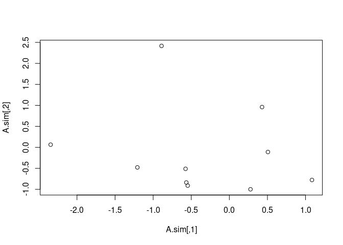

```r
plot(A.sim)
```

```r
(Sigma=cov(matrix(rnorm(20),nrow=10)))
```

```
##            [,1]       [,2]
## [1,] 0.44355769 0.09691591
## [2,] 0.09691591 0.79967563
```

```r
(Sigma.cor=cor(matrix(rnorm(20),nrow=10)))
```

```
##            [,1]       [,2]
## [1,]  1.0000000 -0.4724285
## [2,] -0.4724285  1.0000000
```

```r
Sigma
```

```
##            [,1]       [,2]
## [1,] 0.44355769 0.09691591
## [2,] 0.09691591 0.79967563
```

```r
A=t(chol(Sigma))
A
```

```
##           [,1]      [,2]
## [1,] 0.6660013 0.0000000
## [2,] 0.1455191 0.8823264
```

```r
A%*%t(A)
```

```
##            [,1]       [,2]
## [1,] 0.44355769 0.09691591
## [2,] 0.09691591 0.79967563
```

```r
(x=A%*%rnorm(2))
```

```
##           [,1]
## [1,] 0.4372888
## [2,] 2.3445882
```

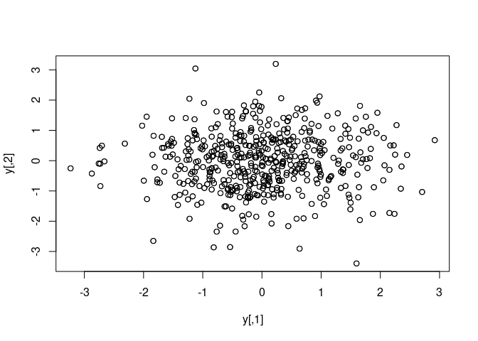

```r
y<-A%*%rnorm(2)
y<-matrix(rnorm(t),t,2,byrow = TRUE)
plot(y)
```

```r
cor(y)
```

```
##            [,1]       [,2]
## [1,] 1.00000000 0.02367179
## [2,] 0.02367179 1.00000000
```

```r
y<-matrix(0,t,2,byrow = TRUE)

for (i in 1:t)
{y[i,]<-A%*%rnorm(2)}
summary(y)
```

```
##        V1                 V2
##  Min.   :-2.06104   Min.   :-2.80664
##  1st Qu.:-0.40632   1st Qu.:-0.58857
##  Median : 0.03102   Median : 0.04620
##  Mean   : 0.02902   Mean   : 0.02158
##  3rd Qu.: 0.50176   3rd Qu.: 0.60406
##  Max.   : 2.10985   Max.   : 2.62540
```

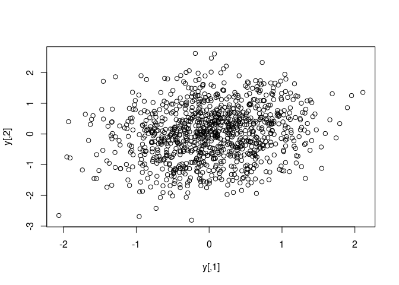

```r
plot(y)
```

```r
cor(y)
```

```
##           [,1]      [,2]
## [1,] 1.0000000 0.1865538
## [2,] 0.1865538 1.0000000
```

# 10 Otra forma de hacerlo

- $\rho$ es coefieciente de correlación
- $x_1 \sim N(0,1)$
- $x_2 \sim N(0,1)$
- $z_{1}=x_{1}$
- $z_{2}=\rho x_{1}+ \sqrt{1-\rho^2}x_{2}$

```r
set.seed(1234)
t<-1000
rho<-Sigma[1,2]
x1<-rnorm(t)
x2<-rnorm(t)
z1<-x1
z2<-rho*z1+sqrt(1-rho**2)*x2
simula<-data.frame(x1,x2,z1,z2)
summary(simula)
```

```
##        x1                 x2                 z1                 z2
##  Min.   :-3.39606   Min.   :-3.12159   Min.   :-3.39606   Min.   :-3.05735
##  1st Qu.:-0.67325   1st Qu.:-0.61721   1st Qu.:-0.67325   1st Qu.:-0.63087
##  Median :-0.03979   Median : 0.01364   Median :-0.03979   Median : 0.01438
##  Mean   :-0.02660   Mean   : 0.01451   Mean   :-0.02660   Mean   : 0.01186
##  3rd Qu.: 0.61582   3rd Qu.: 0.67351   3rd Qu.: 0.61582   3rd Qu.: 0.69620
##  Max.   : 3.19590   Max.   : 3.16794   Max.   : 3.19590   Max.   : 3.38153
```

```r
round(cor(simula),3)
```

```
##       x1    x2    z1    z2
## x1 1.000 0.057 1.000 0.154
## x2 0.057 1.000 0.057 0.995
## z1 1.000 0.057 1.000 0.154
## z2 0.154 0.995 0.154 1.000
```

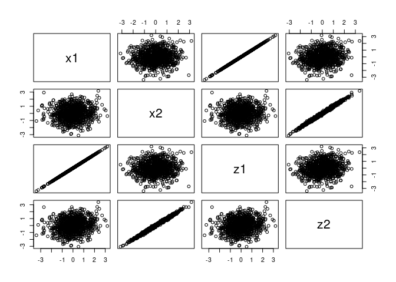

```r
pairs(simula)
```

# 11 Otra forma más de hacerlo

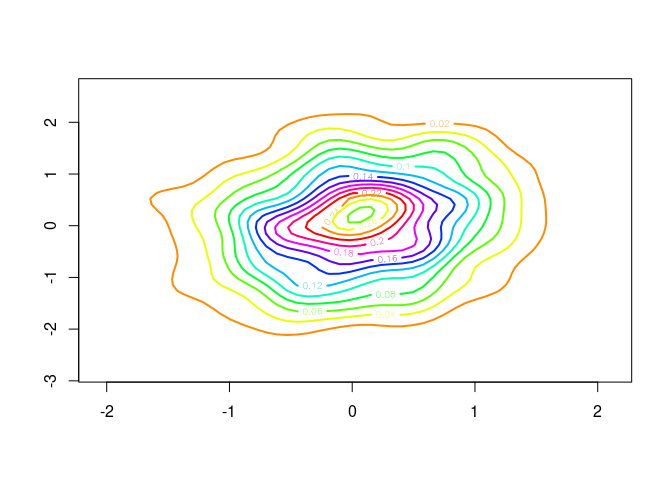

```r
library(MASS)
library(RColorBrewer)
k <- 11
my.cols <- rev(brewer.pal(k, "RdYlBu"))

z34 <- kde2d(y[,1], y[,2], n=50)
contour(z34, drawlabels=TRUE, nlevels=k, col=rainbow(k), add=FALSE,lwd=2)
```

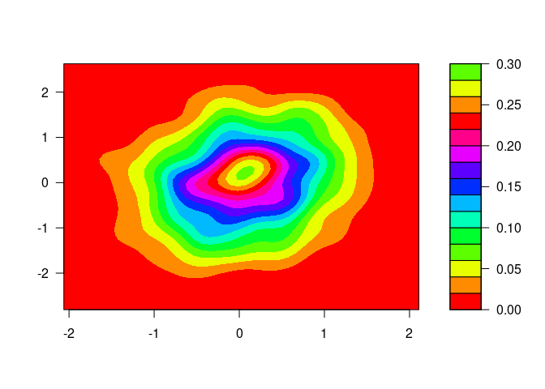

```r
filled.contour(z34$x,z34$y,z34$z,nlevels=k,col = rainbow(k))
```

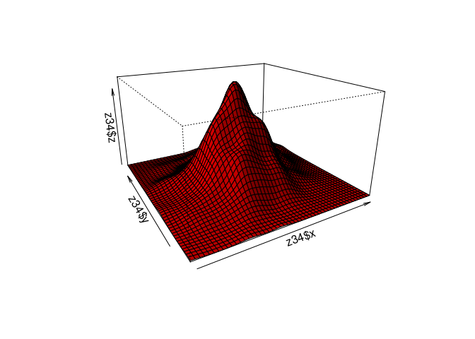

```r
persp(z34$x,z34$y,z34$z, theta = -30, phi = 20, expand = 0.55, col = "red",shade = 0.45,scale=TRUE)
```

# 12 Simulacion de normal multivariada con libreria rmnorm mnormt

```r
library(mnormt)


x <- seq(-2, 4, length=21)
y <- cos(2*x) + 10
z <- x + sin(3*y)
mu <- c(1,12,2)
Sigma <- matrix(c(1,2,0,2,5,0.5,0,0.5,3), 3, 3)
f <- dmnorm(cbind(x,y,z), mu, Sigma)
f0 <- dmnorm(mu, mu, Sigma)
p1 <- pmnorm(c(2,11,3), mu, Sigma)
p2 <- pmnorm(c(2,11,3), mu, Sigma, maxpts=10000, abseps=1e-10)
p <- pmnorm(cbind(x,y,z), mu, Sigma)
#
set.seed(123)
x1 <- rmnorm(5, mu, Sigma)
set.seed(123)
x2 <- rmnorm(5, mu, sqrt=chol(Sigma)) # x1=x2
eig <- eigen(Sigma, symmetric = TRUE)
R <- t(eig$vectors %*% diag(sqrt(eig$values)))
for(i in 1:50) x <- rmnorm(5, mu, sqrt=R)
#
p <- sadmvn(lower=c(2,11,3), upper=rep(Inf,3), mu, Sigma) # upper tail
#
p0 <- pmnorm(c(2,11), mu[1:2], Sigma[1:2,1:2])
p1 <- biv.nt.prob(0, lower=rep(-Inf,2), upper=c(2, 11), mu[1:2], Sigma[1:2,1:2])
p2 <- sadmvn(lower=rep(-Inf,2), upper=c(2, 11), mu[1:2], Sigma[1:2,1:2])
c(p0, p1, p2, p0-p1, p0-p2)
```

```
## [1] 0.3273202 0.3273202 0.3273202 0.0000000 0.0000000
```

```r
#
p1 <- pnorm(0, 1, 3)
p2 <- pmnorm(0, 1, 3^2)
```

# 13 Simulacion de una discreta

```r
Nsim=10^4; lambda=100
spread=3*sqrt(lambda)
t=round(seq(max(0,lambda-spread),lambda+spread,1))
t=round(seq(max(0),150,1))
prob=ppois(t, lambda)
X=rep(0,Nsim)
U<-rep(0,Nsim)
for (i in 1:Nsim){
  u=runif(1)
  U[i]<-u
  X[i]=t[1]+sum(prob<u) }
```

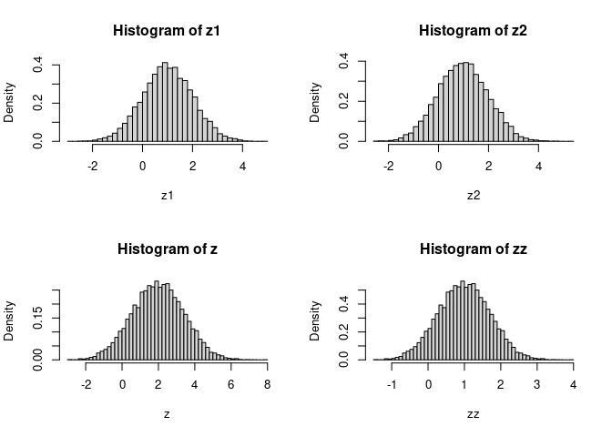

```r
z1 <- rnorm(10000, mean=1, sd=1)
z2 <- rnorm(10000, mean=1, sd=1)
z<-z1+z2
zz<-z1*0.5+z2*0.5

par(mfrow=c(2,2))

hist(z1,breaks = 50,probability = TRUE)
hist(z2,breaks = 50,probability = TRUE)
hist(z,breaks = 50,probability = TRUE)
hist(zz,breaks = 50,probability = TRUE)
```

# 14 Ejemplo estraido de !http://stats.stackexchange.com/questions/70855/simulating-random-variables-from-a-mixture-of-normal-distributions

# 15 Muestra de N uniformes U

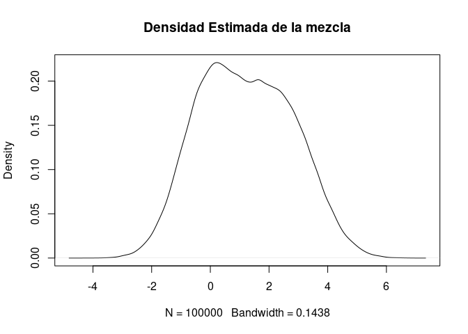

```r
N = 100000
U =runif(N)

#Variable para amacenar las muestras de la mezcla
rand.samples = rep(NA,N)

#Muestreamos de la mezcla
for(i in 1:N){
  if(U[i]<.5){
    rand.samples[i] = rnorm(1,0,1)
  }else if(U[i]<.8){
    rand.samples[i] = rnorm(1,2,1)
  }else{
    rand.samples[i] = rnorm(1,3,1)
  }
}

#Densidad de las muestras
plot(density(rand.samples),main="Densidad Estimada de la mezcla")
```

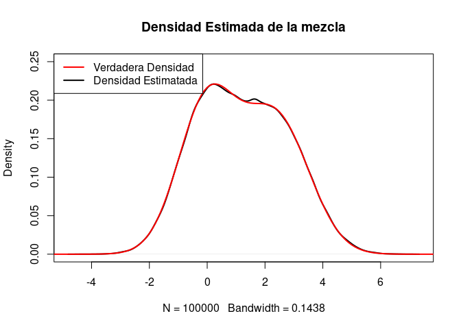

```r
#Plotting the true density as a sanity check
x = seq(-20,20,.1)
truth = .5*dnorm(x,0,1) + 0.3*dnorm(x,2,1) + .2*dnorm(x,3,1)
plot(density(rand.samples),main="Densidad Estimada de la mezcla",ylim=c(0,.25),lwd=2)
lines(x,truth,col="red",lwd=2)

legend("topleft",c("Verdadera Densidad","Densidad Estimatada"),col=c("red","black"),lwd=2)
```

# 16 Simulacion de una student

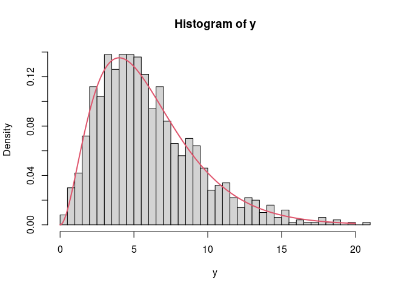

```r
Nsim=1000
y<-rchisq(Nsim,6)


hist(y,breaks = 50,probability = TRUE)
lines(seq(0,20,0.01),dchisq(seq(0,20,0.01),6),lwd=2,col=2)
```

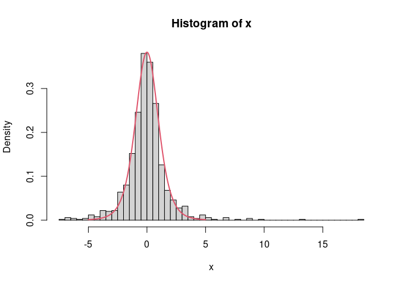

```r
x<-rnorm(Nsim,0,6/y)


hist(x,breaks=50,probability = TRUE)
lines(seq(-5,5,0.01),dt(seq(-5,5,0.01),6),lwd=2,col=2)
```

# 17 Simulacion de una Binomial Negativa

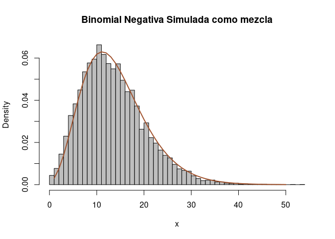

```r
Nsim=10^4
n=6;p=.3
y=rgamma(Nsim,n,rate=p/(1-p))
x=rpois(Nsim,y)
hist(x,freq=F,col="grey",breaks=40,main="Binomial Negativa Simulada como mezcla")
lines(1:50,dnbinom(1:50,n,p),lwd=2,col="sienna")
```